# Regressing Automobile Attributes

Robin Chauhan

2015-06-16

### Executive Summary

After exploratory data analysis, we examine a selection of models to choose an appropriate one. Our findings are as follows:

- Manual transmission on average has 7.24 higher mpgs, or 42.3 percent higher mpg values
- Increased weight reduces mpgs. This reduction is higher for manual transmissions (6.6 mpg per tonne) vs automatic (2.4 per tonne)
- Increased cyliders also reduces mpgs, by 1.2 per cylinder

### Emperical Solution

In the simplest sense, we can find the average mpgs for both types of transmissions:

```r
auto<-subset(mtcars, am==0)
manu<-subset(mtcars, am==1)
cbind(mean(manu$mpg),mean(auto$mpg))
```

```
##          [,1]     [,2]
## [1,] 24.39231 17.14737
```

So manual transmissions are generally 7.24 higher, or 42.3 percent higher. Let’s look into the factors which contribute to this difference.

### Select from Multiple Models

Comparing Adjusted R-squared values for the linear model with only am vs with additional terms:

```r
rbind(summary(lm(mpg~am))$adj.r.squared,
summary(lm(mpg~wt))$adj.r.squared,
summary(lm(mpg~cyl))$adj.r.squared,
summary(lm(mpg~wt+am))$adj.r.squared,
summary(lm(mpg~cyl+am))$adj.r.squared,
summary(lm(mpg~cyl+wt+am))$adj.r.squared,
summary(lm(mpg~cyl+wt+am+qsec))$adj.r.squared)
```

```
##           [,1]
## [1,] 0.3384589
## [2,] 0.7445939
## [3,] 0.7170527
## [4,] 0.7357889
## [5,] 0.7423938
## [6,] 0.8121603
## [7,] 0.8289220
```

From this we conclude that am alone is not a great model, adding wt and cyl helps, and adding qsec has minimal improvements.

We now inspect ANOVA for models that include am, wt, cyl, qsec:

```r
anova( lm(mpg~am), lm(mpg~am+wt), lm(mpg~am+wt+cyl), lm(mpg~am+wt+cyl+qsec))
```

```
## Analysis of Variance Table
##
## Model 1: mpg ~ am
## Model 2: mpg ~ am + wt
## Model 3: mpg ~ am + wt + cyl
## Model 4: mpg ~ am + wt + cyl + qsec
##   Res.Df    RSS Df Sum of Sq       F    Pr(>F)
## 1     30 720.90
## 2     29 278.32  1    442.58 71.2196 4.734e-09 ***
## 3     28 191.05  1     87.27 14.0439 0.0008597 ***
## 4     27 167.78  1     23.26  3.7434 0.0635588 .
## ---
## Signif. codes:  0 '***' 0.001 '**' 0.01 '*' 0.05 '.' 0.1 ' ' 1
```

Based on the P values, we include wt and cyl (p<0.01). However we exclude qsec due to the high Pvalue (0.064). In the Appendix we find diagnostic plots with these terms, including variations that include interactions with am.

We select a model with reasonable diagnostics, good adjusted R-squared, and strong p-values:

```r
summary(lm(mpg~factor(am)*wt+cyl))$coeff
```

```
##                 Estimate Std. Error   t value     Pr(>|t|)
## (Intercept)    34.282998  2.7964507 12.259468 1.518742e-12
## factor(am)1    11.938516  3.8453256  3.104683 4.438319e-03
## wt             -2.368930  0.8243992 -2.873523 7.815636e-03
## cyl            -1.181366  0.3802985 -3.106417 4.419268e-03
## factor(am)1:wt -4.197434  1.3115498 -3.200362 3.496375e-03
```

### Interpretting Results

From this model we find:

- Intercepts
  - Automatic transmission: 34.3
  - Manual transmission: 46.24
- Mpg decreases for each tonne of weight
  - Automatic transmission: -2.4
  - Manual transmission: -6.6
- Mpg decreases by 1.18 for each additional cylinder

### Uncertainty

```r
confint(lm(mpg~factor(am)*wt+cyl))
```

```
##                    2.5 %     97.5 %
## (Intercept)    28.545155 40.0208405
## factor(am)1     4.048559 19.8284725
## wt             -4.060457 -0.6774023
## cyl            -1.961674 -0.4010575
## factor(am)1:wt -6.888512 -1.5063563
```

From this we see that our confidence intervals are generally very broad, so the model should not be considered highly accurate.

# Appendix

### Exploratory Data Analysis

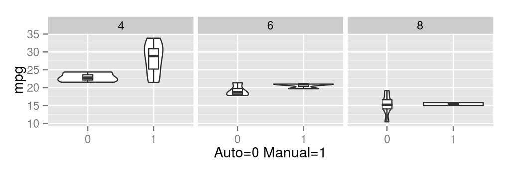

```r
ggplot(mtcars, aes(y=mpg,x=factor(am)))+geom_violin()+geom_boxplot(width=.2)+
  xlab("Auto=0 Manual=1") + facet_grid(.~cyl)
```

Now looking at interaction between wt, am, cyl, and mpg:

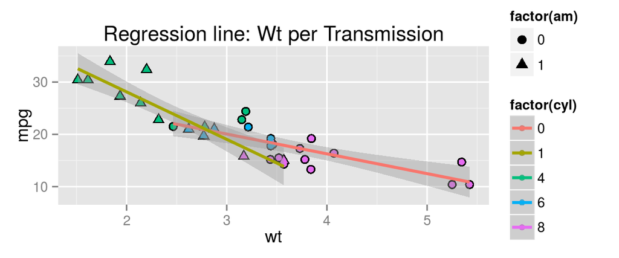

```r
ggplot(mtcars, aes(y=mpg,x=wt, color=factor(cyl),shape=factor(am) ))+
 geom_point(color="black",size=3)+geom_point(size=2)+
 geom_smooth(aes(group=am,color=factor(am)), method="lm",
 size=1, se=T)+ ggtitle("Regression line: Wt per Transmission")
```

### Diagnostic Plots

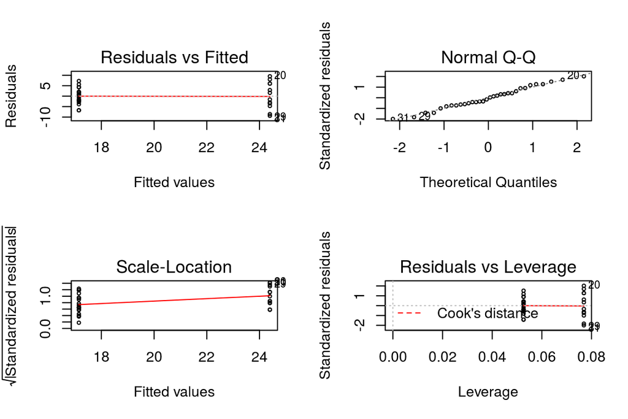

```r
par(mfrow=c(2,2))
plot(lm(mpg~am),cex=0.5)
```

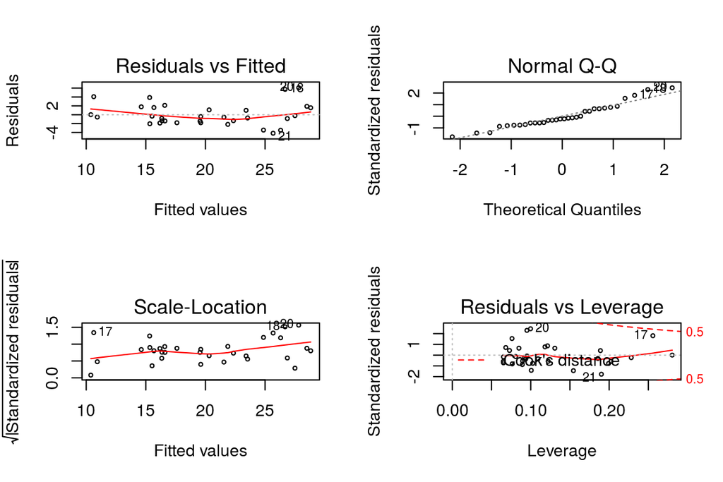

```r
plot(lm(mpg~am+wt+cyl),cex=0.5)
```

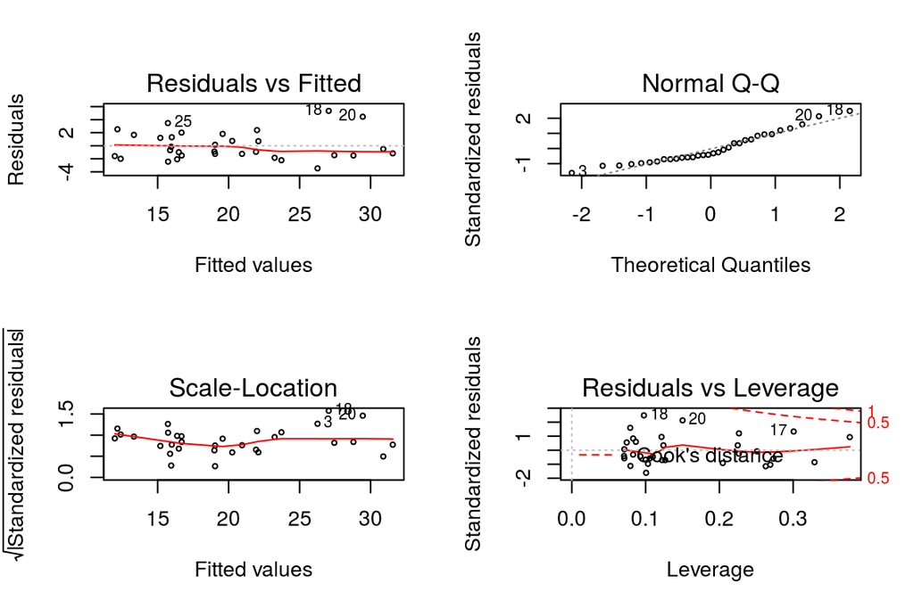

```r
plot(lm(mpg~am*wt+cyl),cex=0.5)
```

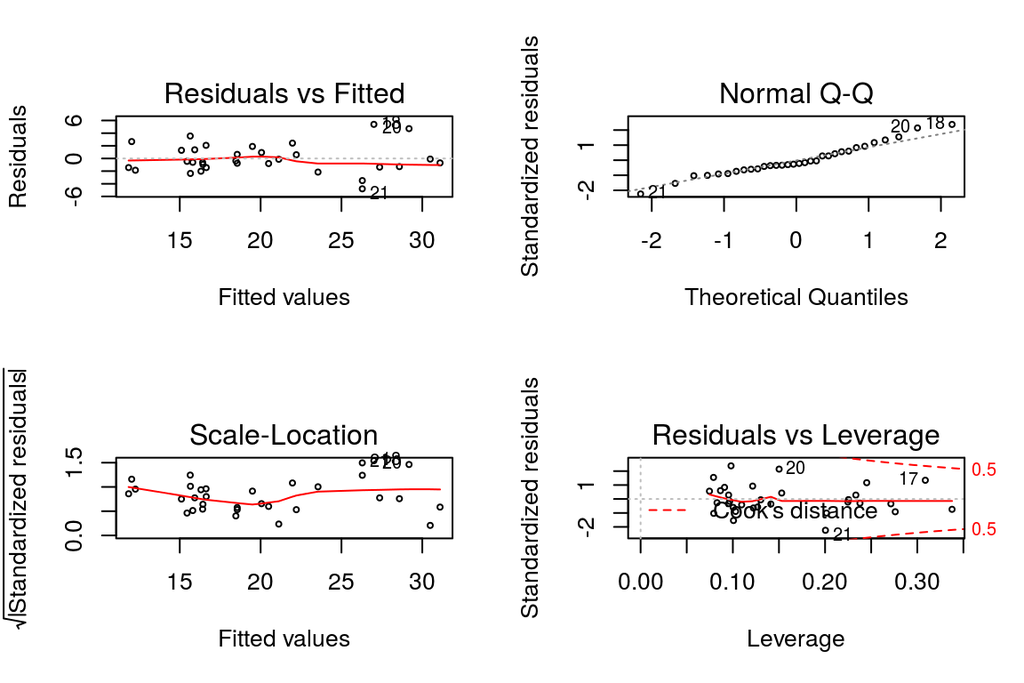

```r
plot(lm(mpg~am+wt*cyl),cex=0.5)
```